# INFO 201/PS5

```r
avg_life_exp_2019 <- data %>%
  filter(!is.na(region)) %>%
  filter(time == 2019) %>%
  group_by(region) %>%
  summarise(avg_life_exp = mean(lifeExpectancy, na.rm = TRUE))

avg_life_exp_2019
```

```
## # A tibble: 5 × 2
##   region   avg_life_exp
##   <chr>           <dbl>
## 1 Africa           64.1
## 2 Americas         75.8
## 3 Asia             74.6
## 4 Europe           79.4
## 5 Oceania          73.5
```

5. I found out that the Africa has the largest average growth rate, while Europe has the smallest average growth rate.Americas and Oceania have similar average growth rate.

```r
time_range <- c(1960, 2019)

life_exp_growth <- data %>%
  filter(time %in% time_range) %>%
  group_by(region, name) %>%
  arrange(name, time) %>%
  mutate(prev = lag(lifeExpectancy)) %>%
  filter(!is.na(prev), !is.na(region)) %>%
  summarise(growth_rate = (lifeExpectancy - prev) / prev, .groups = 'drop') %>%
  group_by(region) %>%
  summarise(avg_growth_rate = mean(growth_rate)) %>%
  arrange(avg_growth_rate)

life_exp_growth
```

```
## # A tibble: 5 × 2
##   region   avg_growth_rate
##   <chr>              <dbl>
## 1 Europe             0.162
## 2 Americas           0.309
## 3 Oceania            0.325
## 4 Asia               0.493
## 5 Africa             0.563
```

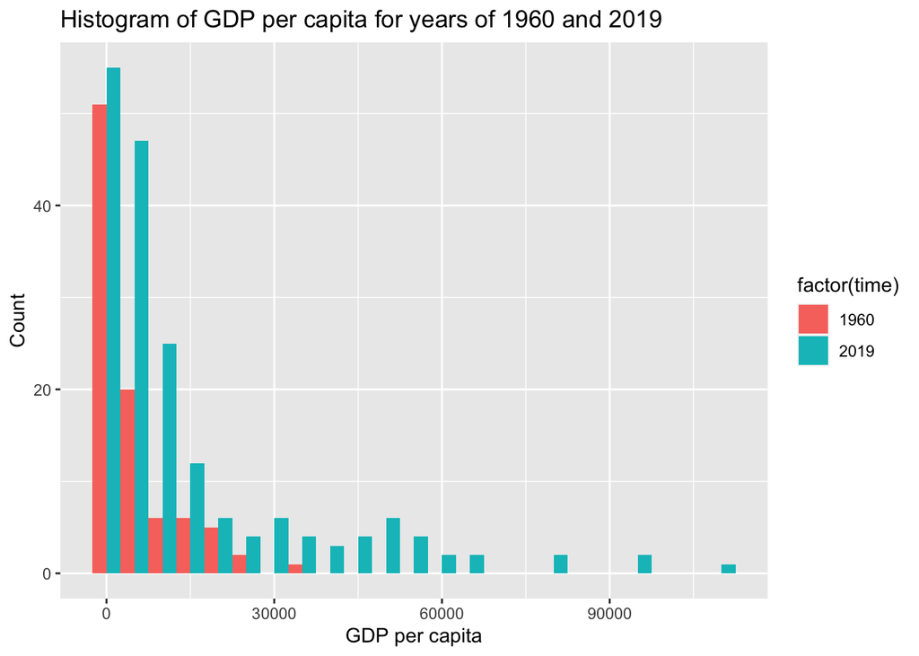

```r
data_1960_2019 <- data %>%
  filter(time %in% time_range)

ggplot(data_1960_2019, aes(x = GDP_PC, fill = factor(time))) +
  geom_histogram(binwidth = 5000, position = "dodge") +
  labs(title = "Histogram of GDP per capita for years of 1960 and 2019",
       x = "GDP per capita",
       y = "Count")
```

7. The ranking for US is 17 in 1960 and 46 in 2019.

```r
us_rank <- data %>%
  filter(time %in% time_range, !is.na(name), !is.na(lifeExpectancy)) %>%
  group_by(time) %>%
  mutate(rank = rank(desc(lifeExpectancy))) %>%
  filter(name == "United States of America") %>%
  select(name, rank)
us_rank
```

```
## # A tibble: 2 × 3
## # Groups:   time [2]
##    time name                      rank
##   <dbl> <chr>                    <dbl>
## 1  1960 United States of America    17
## 2  2019 United States of America    46
```

8. In the relative ranking table, I found that US ranking’s decreases is not that immediate. In relative ranking, US ranks roughly 0.09 in 1960 and 0.23 in 2019.

```r
us_relative_rank <- data %>%
  filter(time %in% time_range, !is.na(name), !is.na(lifeExpectancy)) %>%
  group_by(time) %>%
  mutate(rank = rank(desc(lifeExpectancy)), num_countries = n_distinct(name), relative = rank / num_countries) %>%
  filter(name == "United States of America") %>%
  select(name, rank, num_countries, relative)
us_relative_rank
```

```
## # A tibble: 2 × 5
## # Groups:   time [2]
##    time name                      rank num_countries relative
##   <dbl> <chr>                    <dbl>         <int>    <dbl>
## 1  1960 United States of America    17           188   0.0904
## 2  2019 United States of America    46           196   0.235
```

## Finally:

I spent around 8 hours on this PS